# Does college major contribute to difference in the income?

## Introduction

The libarary containing the dataset is loaded in R environment and the dataset is imported in the memory.

```r
library(dplyr)
```

```r
library(ggplot2)
library(collegeIncome)
data(college)
```

## Dataset codebook

- rank: Rank by median earnings
- major_code: Major code
- major: Major description
- major_category: Category of major
- total: Total number of people with major
- sample_size: Sample size of full-time, year-round individuals used for income/earnings estimates: p25th, median, p75th
- p25th: 25th percentile of earnings
- median: Median earnings of full-time, year-round workers
- p75th: 75th percentile of earnings
- perc_men: % men with major (out of total) perc_women: % women with major (out of total)
- perc_employed: % employed (out of total)
- perc_employed_fulltime: % employed 35 hours or more (out of employed)
- perc_employed_parttime: % employed less than 35 hours (out of employed)
- perc_employed_fulltime_yearround: % employed at least 50 weeks and at least 35 hours (out of employed and full-time)
- perc_unemployed: % unemployed (out of employed)
- perc_college_jobs: % with job requiring a college degree (out of employed)
- perc_non_college_jobs: % with job not requiring a college degree (out of employed)
- perc_low_wage_jobs: % in low-wage service jobs (out of total)

## Quick overview of the dataset

The dataset is quickly reviewed using the *head* an *str* function.

```r
head(college)
```

```
##   rank major_code                                     major major_category
## 1    1       2419                     Petroleum Engineering    Engineering
## 2    2       2416            Mining And Mineral Engineering    Engineering
## 3    3       2415                 Metallurgical Engineering    Engineering
## 4    4       2417 Naval Architecture And Marine Engineering    Engineering
## 5    5       2405                      Chemical Engineering    Engineering
## 6    6       2418                       Nuclear Engineering    Engineering
##   total sample_size perc_women p25th median  p75th   perc_men perc_employed
## 1  2339          36  0.9109326 25000  40000  50000 0.08906743     0.9115044
## 2   756           7  0.5154064 26000  37000  40000 0.48459355     0.7980501
## 3   856           3  0.5942076 26700  45000  60000 0.40579235     0.7871943
## 4  1258          16  0.6521298 26000  35000  45000 0.34787018     0.8465608
## 5 32260         289  0.4179248 31500  62000 109000 0.58207520     0.8515625
## 6  2573          17  0.4305368 23000  44700  50000 0.56946324     0.8474507
##   perc_employed_fulltime perc_employed_parttime
```

[output cut: 20 more lines]

```r
str(college)
```

```
## 'data.frame':    173 obs. of  19 variables:
##  $ rank                            : int  1 2 3 4 5 6 7 8 9 10 ...
##  $ major_code                      : int  2419 2416 2415 2417 2405 2418 6202 5001 2414 2408 ...
##  $ major                           : chr  "Petroleum Engineering" "Mining And Mineral Engineering" "Metallurgical Engineering" "Naval Architecture And Marine Engineering" ...
##  $ major_category                  : chr  "Engineering" "Engineering" "Engineering" "Engineering" ...
##  $ total                           : int  2339 756 856 1258 32260 2573 3777 1792 91227 81527 ...
##  $ sample_size                     : int  36 7 3 16 289 17 51 10 1029 631 ...
##  $ perc_women                      : num  0.911 0.515 0.594 0.652 0.418 ...
##  $ p25th                           : num  25000 26000 26700 26000 31500 23000 32500 37900 29200 23000 ...
##  $ median                          : num  40000 37000 45000 35000 62000 44700 45000 57000 36000 32200 ...
##  $ p75th                           : num  50000 40000 60000 45000 109000 50000 58000 67000 46000 47100 ...
##  $ perc_men                        : num  0.0891 0.4846 0.4058 0.3479 0.5821 ...
##  $ perc_employed                   : num  0.912 0.798 0.787 0.847 0.852 ...
##  $ perc_employed_fulltime          : num  0.921 0.711 0.883 0.937 0.809 ...
##  $ perc_employed_parttime          : num  0.177 0.362 0.339 0.167 0.402 ...
##  $ perc_employed_fulltime_yearround: num  0.77 0.709 0.774 0.653 0.685 ...
##  $ perc_unemployed                 : num  0.0885 0.2019 0.2128 0.1534 0.1484 ...
##  $ perc_college_jobs               : num  0.67 0.387 0.729 0.246 0.587 ...
##  $ perc_non_college_jobs           : num  0.182 0.516 0.176 0.411 0.386 ...
##  $ perc_low_wage_jobs              : num  0.0554 0.2156 0.0301 0.0432 0.118 ...
```

A basic analysis of the average income for each category is performed.

```r
college_tmp <- college %>% select(major_category, median, p25th, p75th)
college2 <- college_tmp %>% group_by(major_category) %>% summarize(median_mean = mean(median, na.rm = TRUE), p25th_mean = mean(p25th, na.rm = TRUE), p75th_mean = mean(p75th, na.rm = TRUE))
college2 <- college2 %>% arrange(desc(median_mean))
college2
```

```
## # A tibble: 16 x 4
##    major_category                      median_mean p25th_mean p75th_mean
##    <chr>                                     <dbl>      <dbl>      <dbl>
##  1 Business                                 49154.     37208.     58862.
##  2 Biology & Life Science                   43864.     32457.     56214.
##  3 Agriculture & Natural Resources          43500      30300      53600
##  4 Communications & Journalism              42000      34000      50000
##  5 Industrial Arts & Consumer Services      40429.     30429.     51029.
##  6 Physical Sciences                        40400      31280      50900
##  7 Engineering                              40393.     28662.     53379.
##  8 Health                                   40317.     28917.     50750
##  9 Psychology & Social Work                 39889.     31067.     50889.
## 10 Social Science                           39067.     28956.     52556.
## 11 Arts                                     38050      28775      45262.
## 12 Education                                37938.     25616.     52375
## 13 Law & Public Policy                      37800      27600      49400
## 14 Humanities & Liberal Arts                35167.     25967.     46133.
## 15 Computers & Mathematics                  34718.     26545.     44455.
## 16 Interdisciplinary                        27500      22900      38000
```

The 3 higher median incomes is associated with a major in 1. Business, 2. Biology & Life Sciences and 3. Agriculture & Natural Resources. The 3 lower incomes are Humanities & Liberal Arts, Computers & Mathematics and Interdisciplinary.

In order to check the distribution for each major category and the p25th, median and p75th income, a boxplot is generated. The distribution of each quantiles per major category do not show any trend, suggesting that the income is independent of the major.

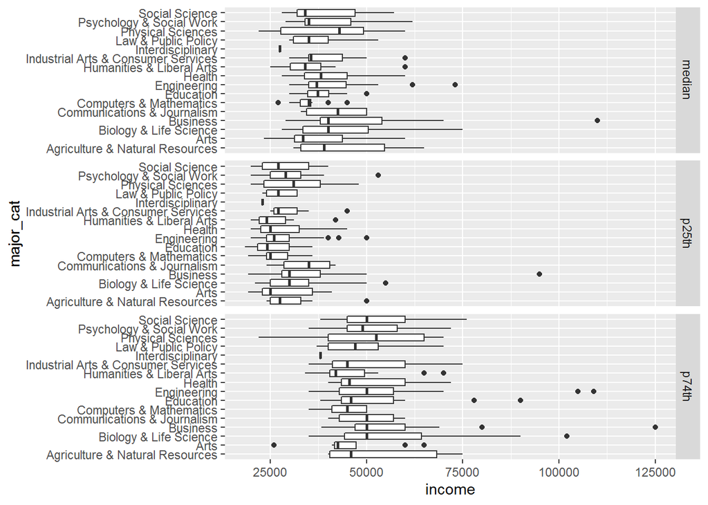

```r
major_cat <- rep(college_tmp$major_category, times = 3)
income_cat <- rep(c("median", "p25th", "p74th"), each = length(college_tmp$major_category))
income <- c(college_tmp$median, college_tmp$p25th, college_tmp$p75th)
college_tmp2 <- data.frame(cbind(major_cat, income_cat, income))
college_tmp2[,3] <- as.numeric(college_tmp2[,3])
g <- ggplot(college_tmp2, aes(income, major_cat))
g + geom_boxplot() + facet_grid(income_cat~.)
```

## Regression model

A regression models is generateed from the dataset where the median as the outcome and the major category as the factor.

```r
fit <- lm(median ~ major_category - 1, college_tmp)
round(summary(fit)$coef, 3)
```

```
##                                                   Estimate Std. Error t value
## major_categoryAgriculture & Natural Resources     43500.00   3590.819  12.114
## major_categoryArts                                38050.00   4014.658   9.478
## major_categoryBiology & Life Science              43864.29   3034.796  14.454
## major_categoryBusiness                            49153.85   3149.357  15.608
## major_categoryCommunications & Journalism         42000.00   5677.583   7.398
## major_categoryComputers & Mathematics             34718.18   3423.712  10.141
## major_categoryEducation                           37937.50   2838.792  13.364
## major_categoryEngineering                         40393.10   2108.602  19.156
## major_categoryHealth                              40316.67   3277.954  12.299
## major_categoryHumanities & Liberal Arts           35166.67   2931.891  11.995
## major_categoryIndustrial Arts & Consumer Services 40428.57   4291.850   9.420
## major_categoryInterdisciplinary                   27500.00  11355.167   2.422
## major_categoryLaw & Public Policy                 37800.00   5078.185   7.444
## major_categoryPhysical Sciences                   40400.00   3590.819  11.251
## major_categoryPsychology & Social Work            39888.89   3785.056  10.539
## major_categorySocial Science                      39066.67   3785.056  10.321
##                                                   Pr(>|t|)
## major_categoryAgriculture & Natural Resources        0.000
## major_categoryArts                                   0.000
## major_categoryBiology & Life Science                 0.000
## major_categoryBusiness                               0.000
## major_categoryCommunications & Journalism            0.000
## major_categoryComputers & Mathematics                0.000
## major_categoryEducation                              0.000
## major_categoryEngineering                            0.000
## major_categoryHealth                                 0.000
## major_categoryHumanities & Liberal Arts              0.000
## major_categoryIndustrial Arts & Consumer Services    0.000
## major_categoryInterdisciplinary                      0.017
## major_categoryLaw & Public Policy                    0.000
## major_categoryPhysical Sciences                      0.000
## major_categoryPsychology & Social Work               0.000
## major_categorySocial Science                         0.000
```

Let’s compare now the median income from the major category business compared to the rest.

```r
major_cat2 <- relevel(as.factor(college_tmp$major_category), "Business" )
fit2 <- lm(median ~ major_cat2, college_tmp)
summary(fit2)
```

```
##
## Call:
## lm(formula = median ~ major_cat2, data = college_tmp)
##
## Residuals:
##    Min     1Q Median     3Q    Max
## -20154  -6800  -2893   4833  60846
##
## Coefficients:
##                                               Estimate Std. Error t value
## (Intercept)                                      49154       3149  15.608
## major_cat2Agriculture & Natural Resources        -5654       4776  -1.184
## major_cat2Arts                                  -11104       5102  -2.176
## major_cat2Biology & Life Science                 -5290       4374  -1.209
## major_cat2Communications & Journalism            -7154       6493  -1.102
## major_cat2Computers & Mathematics               -14436       4652  -3.103
## major_cat2Education                             -11216       4240  -2.645
## major_cat2Engineering                            -8761       3790  -2.311
## major_cat2Health                                 -8837       4546  -1.944
## major_cat2Humanities & Liberal Arts             -13987       4303  -3.251
## major_cat2Industrial Arts & Consumer Services    -8725       5323  -1.639
## major_cat2Interdisciplinary                     -21654      11784  -1.838
## major_cat2Law & Public Policy                   -11354       5976  -1.900
## major_cat2Physical Sciences                      -8754       4776  -1.833
## major_cat2Psychology & Social Work               -9265       4924  -1.882
## major_cat2Social Science                        -10087       4924  -2.049
##                                               Pr(>|t|)
## (Intercept)                                    < 2e-16 ***
## major_cat2Agriculture & Natural Resources      0.23830
## major_cat2Arts                                 0.03104 *
## major_cat2Biology & Life Science               0.22832
## major_cat2Communications & Journalism          0.27221
## major_cat2Computers & Mathematics              0.00227 **
## major_cat2Education                            0.00899 **
## major_cat2Engineering                          0.02211 *
## major_cat2Health                               0.05367 .
## major_cat2Humanities & Liberal Arts            0.00141 **
## major_cat2Industrial Arts & Consumer Services  0.10321
## major_cat2Interdisciplinary                    0.06801 .
## major_cat2Law & Public Policy                  0.05926 .
## major_cat2Physical Sciences                    0.06873 .
## major_cat2Psychology & Social Work             0.06174 .
## major_cat2Social Science                       0.04217 *
## ---
## Signif. codes:  0 '***' 0.001 '**' 0.01 '*' 0.05 '.' 0.1 ' ' 1
##
## Residual standard error: 11360 on 157 degrees of freedom
## Multiple R-squared:  0.1054, Adjusted R-squared:  0.01995
## F-statistic: 1.233 on 15 and 157 DF,  p-value: 0.2522
```

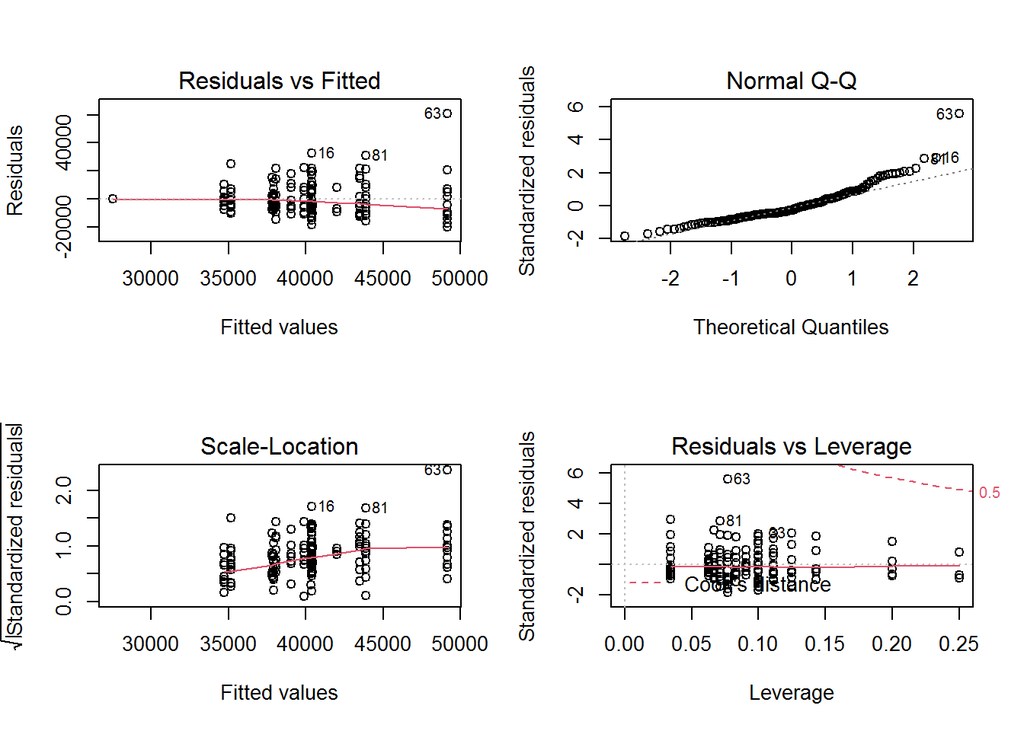

```r
par(mfrow = c(2,2))
plot(fit2)
```

By comparing the major category **Business** to the other categories, we can observe a clear difference with some major categories. There is a significant difference (p-value < 0.05) when compared to **Arts**, **Computers and Mathematics**, **Education**, **Engineering**, **Humanities & Liberal Arts** and **Social Science**.

## Conclusion

In order to answer the question below, a basic analysis was performed.

**Question:** Based on your analysis, would you conclude that there is a significant association between college major category and income?

The assumptions could have been stated as the following: * NULL hypothesis: there is no difference in the mean of the incomes when holding a specific major. * Alternative hypothesis: There is a difference in the mean of the incomes between major categories.

Our basic analysis shows that there is a difference between some major and some other majors. There is a significant difference (p-value < 0.05) btween **Business** compared to **Arts**, **Computers and Mathematics**, **Education**, **Engineering**, **Humanities & Liberal Arts** and **Social Science**.